# Risk Factor Analysis

## Outcome Variable

**Outcome Variable:** haz

## Predictor Variables

**Intervention Variable:** enwast

**Adjustment Set:**

unadjusted

## Stratifying Variables

The analysis was stratified on these variable(s):

- agecat
- studyid
- country

## Data Summary

| agecat | studyid | country | enwast | n_cell | n |
| --- | --- | --- | --- | --- | --- |
| Birth | CMC-V-BCS-2002 | INDIA | 0 | 75 | 87 |
| Birth | CMC-V-BCS-2002 | INDIA | 1 | 12 | 87 |
| Birth | CMIN | BANGLADESH | 0 | 15 | 19 |
| Birth | CMIN | BANGLADESH | 1 | 4 | 19 |
| Birth | COHORTS | GUATEMALA | 0 | 564 | 762 |
| Birth | COHORTS | GUATEMALA | 1 | 198 | 762 |
| Birth | COHORTS | INDIA | 0 | 5097 | 6231 |
| Birth | COHORTS | INDIA | 1 | 1134 | 6231 |
| Birth | COHORTS | PHILIPPINES | 0 | 2448 | 2910 |
| Birth | COHORTS | PHILIPPINES | 1 | 462 | 2910 |
| Birth | CONTENT | PERU | 0 | 2 | 2 |
| Birth | CONTENT | PERU | 1 | 0 | 2 |
| Birth | EE | PAKISTAN | 0 | 155 | 180 |
| Birth | EE | PAKISTAN | 1 | 25 | 180 |
| Birth | GMS-Nepal | NEPAL | 0 | 509 | 645 |
| Birth | GMS-Nepal | NEPAL | 1 | 136 | 645 |
| Birth | IRC | INDIA | 0 | 251 | 364 |
| Birth | IRC | INDIA | 1 | 113 | 364 |
| Birth | JiVitA-3 | BANGLADESH | 0 | 16041 | 18062 |
| Birth | JiVitA-3 | BANGLADESH | 1 | 2021 | 18062 |
| Birth | JiVitA-4 | BANGLADESH | 0 | 2157 | 2399 |
| Birth | JiVitA-4 | BANGLADESH | 1 | 242 | 2399 |
| Birth | Keneba | GAMBIA | 0 | 1102 | 1488 |
| Birth | Keneba | GAMBIA | 1 | 386 | 1488 |
| Birth | MAL-ED | BANGLADESH | 0 | 179 | 215 |
| Birth | MAL-ED | BANGLADESH | 1 | 36 | 215 |
| Birth | MAL-ED | BRAZIL | 0 | 60 | 62 |
| Birth | MAL-ED | BRAZIL | 1 | 2 | 62 |
| Birth | MAL-ED | INDIA | 0 | 40 | 45 |
| Birth | MAL-ED | INDIA | 1 | 5 | 45 |

[output cut: 134 more lines]

The following strata were considered:

- agecat: 24 months, studyid: CMC-V-BCS-2002, country: INDIA
- agecat: 24 months, studyid: CMIN, country: BANGLADESH
- agecat: 24 months, studyid: COHORTS, country: GUATEMALA
- agecat: 24 months, studyid: COHORTS, country: INDIA
- agecat: 24 months, studyid: COHORTS, country: PHILIPPINES
- agecat: 24 months, studyid: CONTENT, country: PERU
- agecat: 24 months, studyid: EE, country: PAKISTAN
- agecat: 24 months, studyid: GMS-Nepal, country: NEPAL
- agecat: 24 months, studyid: IRC, country: INDIA
- agecat: 24 months, studyid: JiVitA-3, country: BANGLADESH
- agecat: 24 months, studyid: JiVitA-4, country: BANGLADESH
- agecat: 24 months, studyid: Keneba, country: GAMBIA
- agecat: 24 months, studyid: LCNI-5, country: MALAWI
- agecat: 24 months, studyid: MAL-ED, country: BANGLADESH
- agecat: 24 months, studyid: MAL-ED, country: BRAZIL
- agecat: 24 months, studyid: MAL-ED, country: INDIA
- agecat: 24 months, studyid: MAL-ED, country: NEPAL
- agecat: 24 months, studyid: MAL-ED, country: PERU
- agecat: 24 months, studyid: MAL-ED, country: SOUTH AFRICA
- agecat: 24 months, studyid: MAL-ED, country: TANZANIA, UNITED REPUBLIC OF
- agecat: 24 months, studyid: NIH-Birth, country: BANGLADESH
- agecat: 24 months, studyid: NIH-Crypto, country: BANGLADESH
- agecat: 24 months, studyid: PROBIT, country: BELARUS
- agecat: 24 months, studyid: PROVIDE, country: BANGLADESH
- agecat: 24 months, studyid: TanzaniaChild2, country: TANZANIA, UNITED REPUBLIC OF
- agecat: 24 months, studyid: ZVITAMBO, country: ZIMBABWE
- agecat: 6 months, studyid: CMC-V-BCS-2002, country: INDIA
- agecat: 6 months, studyid: CMIN, country: BANGLADESH
- agecat: 6 months, studyid: COHORTS, country: GUATEMALA
- agecat: 6 months, studyid: COHORTS, country: INDIA
- agecat: 6 months, studyid: COHORTS, country: PHILIPPINES
- agecat: 6 months, studyid: CONTENT, country: PERU
- agecat: 6 months, studyid: EE, country: PAKISTAN
- agecat: 6 months, studyid: GMS-Nepal, country: NEPAL
- agecat: 6 months, studyid: Guatemala BSC, country: GUATEMALA
- agecat: 6 months, studyid: IRC, country: INDIA
- agecat: 6 months, studyid: JiVitA-3, country: BANGLADESH
- agecat: 6 months, studyid: JiVitA-4, country: BANGLADESH
- agecat: 6 months, studyid: Keneba, country: GAMBIA
- agecat: 6 months, studyid: LCNI-5, country: MALAWI
- agecat: 6 months, studyid: MAL-ED, country: BANGLADESH
- agecat: 6 months, studyid: MAL-ED, country: BRAZIL
- agecat: 6 months, studyid: MAL-ED, country: INDIA
- agecat: 6 months, studyid: MAL-ED, country: NEPAL
- agecat: 6 months, studyid: MAL-ED, country: PERU
- agecat: 6 months, studyid: MAL-ED, country: SOUTH AFRICA
- agecat: 6 months, studyid: MAL-ED, country: TANZANIA, UNITED REPUBLIC OF
- agecat: 6 months, studyid: NIH-Birth, country: BANGLADESH
- agecat: 6 months, studyid: NIH-Crypto, country: BANGLADESH
- agecat: 6 months, studyid: PROBIT, country: BELARUS
- agecat: 6 months, studyid: PROVIDE, country: BANGLADESH
- agecat: 6 months, studyid: ResPak, country: PAKISTAN
- agecat: 6 months, studyid: SAS-CompFeed, country: INDIA
- agecat: 6 months, studyid: SAS-FoodSuppl, country: INDIA
- agecat: 6 months, studyid: TanzaniaChild2, country: TANZANIA, UNITED REPUBLIC OF
- agecat: 6 months, studyid: ZVITAMBO, country: ZIMBABWE
- agecat: Birth, studyid: CMC-V-BCS-2002, country: INDIA
- agecat: Birth, studyid: CMIN, country: BANGLADESH
- agecat: Birth, studyid: COHORTS, country: GUATEMALA
- agecat: Birth, studyid: COHORTS, country: INDIA
- agecat: Birth, studyid: COHORTS, country: PHILIPPINES
- agecat: Birth, studyid: CONTENT, country: PERU
- agecat: Birth, studyid: EE, country: PAKISTAN
- agecat: Birth, studyid: GMS-Nepal, country: NEPAL
- agecat: Birth, studyid: IRC, country: INDIA
- agecat: Birth, studyid: JiVitA-3, country: BANGLADESH
- agecat: Birth, studyid: JiVitA-4, country: BANGLADESH
- agecat: Birth, studyid: Keneba, country: GAMBIA
- agecat: Birth, studyid: MAL-ED, country: BANGLADESH
- agecat: Birth, studyid: MAL-ED, country: BRAZIL
- agecat: Birth, studyid: MAL-ED, country: INDIA
- agecat: Birth, studyid: MAL-ED, country: NEPAL
- agecat: Birth, studyid: MAL-ED, country: PERU
- agecat: Birth, studyid: MAL-ED, country: SOUTH AFRICA
- agecat: Birth, studyid: MAL-ED, country: TANZANIA, UNITED REPUBLIC OF
- agecat: Birth, studyid: NIH-Birth, country: BANGLADESH
- agecat: Birth, studyid: NIH-Crypto, country: BANGLADESH
- agecat: Birth, studyid: PROBIT, country: BELARUS
- agecat: Birth, studyid: PROVIDE, country: BANGLADESH
- agecat: Birth, studyid: ResPak, country: PAKISTAN
- agecat: Birth, studyid: SAS-CompFeed, country: INDIA
- agecat: Birth, studyid: ZVITAMBO, country: ZIMBABWE

### Dropped Strata

Some strata were dropped due to rare outcomes:

- agecat: Birth, studyid: CMIN, country: BANGLADESH
- agecat: Birth, studyid: CONTENT, country: PERU
- agecat: Birth, studyid: MAL-ED, country: BRAZIL
- agecat: Birth, studyid: MAL-ED, country: NEPAL
- agecat: Birth, studyid: MAL-ED, country: TANZANIA, UNITED REPUBLIC OF
- agecat: Birth, studyid: ResPak, country: PAKISTAN
- agecat: 6 months, studyid: CONTENT, country: PERU
- agecat: 6 months, studyid: MAL-ED, country: TANZANIA, UNITED REPUBLIC OF
- agecat: 24 months, studyid: CONTENT, country: PERU
- agecat: 24 months, studyid: MAL-ED, country: PERU
- agecat: 24 months, studyid: MAL-ED, country: TANZANIA, UNITED REPUBLIC OF
- agecat: 24 months, studyid: TanzaniaChild2, country: TANZANIA, UNITED REPUBLIC OF

## Methods Detail

We’re interested in the causal parameters $E[Y_a]$ for all values of $a \in \mathcal{A}$. These parameters represent the mean outcome if, possibly contrary to fact, we intervened to set all units to have $A=a$. Under the randomization and positivity assumptions, these are identified by the statistical parameters $\psi_a=E_W[E_{Y|A,W}(Y|A=a,W)]$. In addition, we’re interested in the mean of $Y$, $E[Y]$ under no intervention (the observed mean). We will estimate these parameters by using SuperLearner to fit the relevant likelihood factors – $E_{Y|A,W}(Y|A=a,W)$ and $p(A=a|W)$, and then updating our likelihood fit using a joint TMLE.

For unadjusted analyses ($W=\{\}$), initial likelihoods were estimated using Lrnr_glm to estimate the simple $E(Y|A)$ and Lrnr_mean to estimate $p(A)$. For adjusted analyses, a small library containing Lrnr_glmnet, Lrnr_xgboost, and Lrnr_mean was used.

Having estimated these parameters, we will then use the delta method to estimate relative risks and attributable risks relative to a prespecified baseline level of $A$.

# Results Detail

## Results Plots

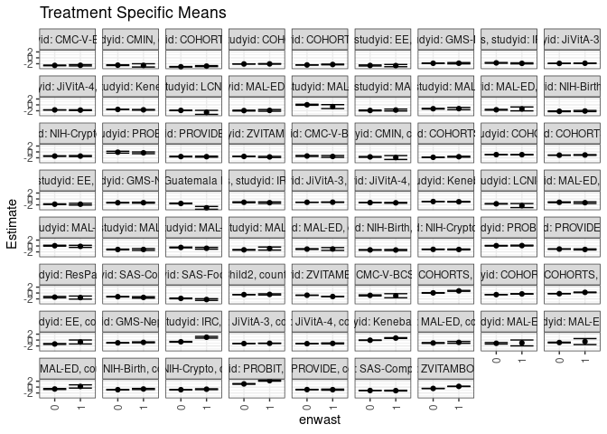

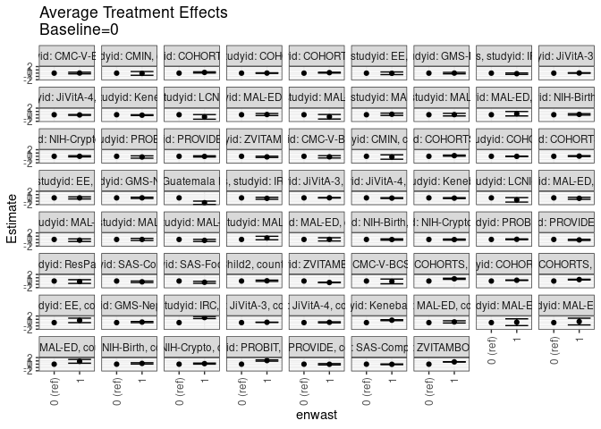

[figure not shown]

## Results Table

### Parameter: TSM

| agecat | studyid | country | intervention_level | baseline_level | estimate | ci_lower | ci_upper |
| --- | --- | --- | --- | --- | --- | --- | --- |
| Birth | CMC-V-BCS-2002 | INDIA | 0 | NA | -0.8024667 | -0.9881514 | -0.6167820 |
| Birth | CMC-V-BCS-2002 | INDIA | 1 | NA | -0.9254167 | -1.6211412 | -0.2296922 |
| Birth | COHORTS | GUATEMALA | 0 | NA | 0.0463298 | -0.0424159 | 0.1350755 |
| Birth | COHORTS | GUATEMALA | 1 | NA | 0.7225253 | 0.5787376 | 0.8663129 |
| Birth | COHORTS | INDIA | 0 | NA | -0.5515951 | -0.5780832 | -0.5251069 |
| Birth | COHORTS | INDIA | 1 | NA | -0.3073104 | -0.3724302 | -0.2421907 |
| Birth | COHORTS | PHILIPPINES | 0 | NA | -0.2184477 | -0.2547450 | -0.1821504 |
| Birth | COHORTS | PHILIPPINES | 1 | NA | 0.2183766 | 0.1141890 | 0.3225643 |
| Birth | EE | PAKISTAN | 0 | NA | -1.3318710 | -1.4721761 | -1.1915658 |
| Birth | EE | PAKISTAN | 1 | NA | -0.6584000 | -1.3284013 | 0.0116013 |
| Birth | GMS-Nepal | NEPAL | 0 | NA | -0.9446758 | -1.0213127 | -0.8680390 |
| Birth | GMS-Nepal | NEPAL | 1 | NA | -0.7883824 | -0.9487455 | -0.6280192 |
| Birth | IRC | INDIA | 0 | NA | -0.5921514 | -0.7120146 | -0.4722882 |
| Birth | IRC | INDIA | 1 | NA | 0.9509735 | 0.6637025 | 1.2382444 |
| Birth | JiVitA-3 | BANGLADESH | 0 | NA | -1.1888137 | -1.2035251 | -1.1741022 |
| Birth | JiVitA-3 | BANGLADESH | 1 | NA | -1.0942108 | -1.1422880 | -1.0461336 |
| Birth | JiVitA-4 | BANGLADESH | 0 | NA | -1.2283635 | -1.2698403 | -1.1868866 |
| Birth | JiVitA-4 | BANGLADESH | 1 | NA | -1.1416116 | -1.3015792 | -0.9816439 |
| Birth | Keneba | GAMBIA | 0 | NA | -0.0568693 | -0.1145426 | 0.0008040 |
| Birth | Keneba | GAMBIA | 1 | NA | 0.6783420 | 0.5534396 | 0.8032443 |
| Birth | MAL-ED | BANGLADESH | 0 | NA | -0.9985475 | -1.1263859 | -0.8707090 |
| Birth | MAL-ED | BANGLADESH | 1 | NA | -0.7836111 | -1.0977298 | -0.4694924 |
| Birth | MAL-ED | INDIA | 0 | NA | -1.0995000 | -1.3601155 | -0.8388845 |
| Birth | MAL-ED | INDIA | 1 | NA | -0.9800000 | -1.9772048 | 0.0172048 |
| Birth | MAL-ED | PERU | 0 | NA | -0.8421525 | -0.9539315 | -0.7303735 |
| Birth | MAL-ED | PERU | 1 | NA | -0.5260000 | -1.5481689 | 0.4961689 |
| Birth | MAL-ED | SOUTH AFRICA | 0 | NA | -0.6523148 | -0.8186939 | -0.4859357 |
| Birth | MAL-ED | SOUTH AFRICA | 1 | NA | 0.2123077 | -0.3340824 | 0.7586978 |
| Birth | NIH-Birth | BANGLADESH | 0 | NA | -0.8860688 | -0.9713719 | -0.8007657 |
| Birth | NIH-Birth | BANGLADESH | 1 | NA | -0.6498266 | -0.8334496 | -0.4662035 |

[output cut: 110 more lines]

### Parameter: E(Y)

| agecat | studyid | country | intervention_level | baseline_level | estimate | ci_lower | ci_upper |
| --- | --- | --- | --- | --- | --- | --- | --- |
| Birth | CMC-V-BCS-2002 | INDIA | NA | NA | -0.8194253 | -1.0062738 | -0.6325768 |
| Birth | COHORTS | GUATEMALA | NA | NA | 0.2220341 | 0.1435838 | 0.3004845 |
| Birth | COHORTS | INDIA | NA | NA | -0.5071369 | -0.5319444 | -0.4823294 |
| Birth | COHORTS | PHILIPPINES | NA | NA | -0.1490962 | -0.1843045 | -0.1138879 |
| Birth | EE | PAKISTAN | NA | NA | -1.2383333 | -1.3946042 | -1.0820625 |
| Birth | GMS-Nepal | NEPAL | NA | NA | -0.9117209 | -0.9811840 | -0.8422578 |
| Birth | IRC | INDIA | NA | NA | -0.1131044 | -0.2551572 | 0.0289484 |
| Birth | JiVitA-3 | BANGLADESH | NA | NA | -1.1782283 | -1.1929469 | -1.1635098 |
| Birth | JiVitA-4 | BANGLADESH | NA | NA | -1.2196123 | -1.2608853 | -1.1783394 |
| Birth | Keneba | GAMBIA | NA | NA | 0.1338508 | 0.0777935 | 0.1899081 |
| Birth | MAL-ED | BANGLADESH | NA | NA | -0.9625581 | -1.0817638 | -0.8433525 |
| Birth | MAL-ED | INDIA | NA | NA | -1.0862222 | -1.3432542 | -0.8291902 |
| Birth | MAL-ED | PERU | NA | NA | -0.8352193 | -0.9473216 | -0.7231170 |
| Birth | MAL-ED | SOUTH AFRICA | NA | NA | -0.5594215 | -0.7261377 | -0.3927053 |
| Birth | NIH-Birth | BANGLADESH | NA | NA | -0.8156034 | -0.8972149 | -0.7339920 |
| Birth | NIH-Crypto | BANGLADESH | NA | NA | -0.8487377 | -0.9161997 | -0.7812758 |
| Birth | PROBIT | BELARUS | NA | NA | 1.3137865 | 1.1546333 | 1.4729398 |
| Birth | PROVIDE | BANGLADESH | NA | NA | -0.8579887 | -0.9311892 | -0.7847883 |
| Birth | SAS-CompFeed | INDIA | NA | NA | -1.1641176 | -1.2153187 | -1.1129166 |
| Birth | ZVITAMBO | ZIMBABWE | NA | NA | -0.3412145 | -0.3591726 | -0.3232564 |
| 6 months | CMC-V-BCS-2002 | INDIA | NA | NA | -1.4223508 | -1.5654032 | -1.2792984 |
| 6 months | CMIN | BANGLADESH | NA | NA | -1.7090230 | -1.8439050 | -1.5741410 |
| 6 months | COHORTS | GUATEMALA | NA | NA | -1.7950277 | -1.8646284 | -1.7254271 |
| 6 months | COHORTS | INDIA | NA | NA | -0.9241887 | -0.9514678 | -0.8969095 |
| 6 months | COHORTS | PHILIPPINES | NA | NA | -1.0928731 | -1.1347142 | -1.0510321 |
| 6 months | EE | PAKISTAN | NA | NA | -1.7873630 | -1.9021295 | -1.6725965 |
| 6 months | GMS-Nepal | NEPAL | NA | NA | -1.2753093 | -1.3514861 | -1.1991326 |
| 6 months | Guatemala BSC | GUATEMALA | NA | NA | -1.5619008 | -1.6727702 | -1.4510313 |
| 6 months | IRC | INDIA | NA | NA | -1.1707373 | -1.3023712 | -1.0391035 |
| 6 months | JiVitA-3 | BANGLADESH | NA | NA | -1.1254416 | -1.1482406 | -1.1026426 |
| 6 months | JiVitA-4 | BANGLADESH | NA | NA | -1.2464966 | -1.2832103 | -1.2097829 |
| 6 months | Keneba | GAMBIA | NA | NA | -0.8918017 | -0.9392551 | -0.8443483 |
| 6 months | LCNI-5 | MALAWI | NA | NA | -1.6601907 | -1.7297701 | -1.5906113 |
| 6 months | MAL-ED | BANGLADESH | NA | NA | -1.1545706 | -1.2720635 | -1.0370777 |
| 6 months | MAL-ED | BRAZIL | NA | NA | 0.0820017 | -0.0652646 | 0.2292679 |
| 6 months | MAL-ED | INDIA | NA | NA | -1.1907471 | -1.3084496 | -1.0730447 |
| 6 months | MAL-ED | NEPAL | NA | NA | -0.5356897 | -0.6466309 | -0.4247484 |
| 6 months | MAL-ED | PERU | NA | NA | -1.3000971 | -1.4087542 | -1.1914400 |
| 6 months | MAL-ED | SOUTH AFRICA | NA | NA | -1.0492424 | -1.1743146 | -0.9241702 |
| 6 months | NIH-Birth | BANGLADESH | NA | NA | -1.3447001 | -1.4316348 | -1.2577653 |
| 6 months | NIH-Crypto | BANGLADESH | NA | NA | -1.1560014 | -1.2261266 | -1.0858763 |
| 6 months | PROBIT | BELARUS | NA | NA | 0.0987124 | 0.0071839 | 0.1902410 |
| 6 months | PROVIDE | BANGLADESH | NA | NA | -1.0728671 | -1.1465641 | -0.9991701 |
| 6 months | ResPak | PAKISTAN | NA | NA | -1.4274196 | -1.6382670 | -1.2165722 |
| 6 months | SAS-CompFeed | INDIA | NA | NA | -1.2781121 | -1.3694457 | -1.1867786 |
| 6 months | SAS-FoodSuppl | INDIA | NA | NA | -1.8986842 | -2.0118892 | -1.7854792 |
| 6 months | TanzaniaChild2 | TANZANIA, UNITED REPUBLIC OF | NA | NA | -0.5424220 | -0.5912180 | -0.4936261 |
| 6 months | ZVITAMBO | ZIMBABWE | NA | NA | -0.8157359 | -0.8414876 | -0.7899842 |
| 24 months | CMC-V-BCS-2002 | INDIA | NA | NA | -2.5559249 | -2.6552739 | -2.4565759 |
| 24 months | CMIN | BANGLADESH | NA | NA | -2.4877155 | -2.6168325 | -2.3585986 |
| 24 months | COHORTS | GUATEMALA | NA | NA | -2.9946835 | -3.0601854 | -2.9291817 |
| 24 months | COHORTS | INDIA | NA | NA | -2.0741479 | -2.1071054 | -2.0411904 |
| 24 months | COHORTS | PHILIPPINES | NA | NA | -2.3841755 | -2.4295300 | -2.3388211 |
| 24 months | EE | PAKISTAN | NA | NA | -2.5941727 | -2.7436756 | -2.4446699 |
| 24 months | GMS-Nepal | NEPAL | NA | NA | -1.8435238 | -1.9304004 | -1.7566473 |
| 24 months | IRC | INDIA | NA | NA | -1.7639600 | -1.8601530 | -1.6677669 |
| 24 months | JiVitA-3 | BANGLADESH | NA | NA | -1.8772038 | -1.9062064 | -1.8482013 |
| 24 months | JiVitA-4 | BANGLADESH | NA | NA | -1.7182341 | -1.7544244 | -1.6820437 |
| 24 months | Keneba | GAMBIA | NA | NA | -1.5730887 | -1.6234321 | -1.5227452 |
| 24 months | LCNI-5 | MALAWI | NA | NA | -1.8861485 | -1.9671802 | -1.8051169 |
| 24 months | MAL-ED | BANGLADESH | NA | NA | -1.9287562 | -2.0568859 | -1.8006265 |
| 24 months | MAL-ED | BRAZIL | NA | NA | 0.0113750 | -0.1608859 | 0.1836359 |
| 24 months | MAL-ED | INDIA | NA | NA | -1.8697758 | -1.9956076 | -1.7439440 |
| 24 months | MAL-ED | NEPAL | NA | NA | -1.2990889 | -1.4193577 | -1.1788201 |
| 24 months | MAL-ED | SOUTH AFRICA | NA | NA | -1.6435830 | -1.7787856 | -1.5083803 |
| 24 months | NIH-Birth | BANGLADESH | NA | NA | -2.1580827 | -2.2606216 | -2.0555438 |
| 24 months | NIH-Crypto | BANGLADESH | NA | NA | -1.4121200 | -1.4955578 | -1.3286822 |
| 24 months | PROBIT | BELARUS | NA | NA | -0.1437293 | -0.4231910 | 0.1357324 |
| 24 months | PROVIDE | BANGLADESH | NA | NA | -1.5877105 | -1.6705437 | -1.5048773 |
| 24 months | ZVITAMBO | ZIMBABWE | NA | NA | -1.5460133 | -1.6038691 | -1.4881575 |

### Parameter: ATE

| agecat | studyid | country | intervention_level | baseline_level | estimate | ci_lower | ci_upper |
| --- | --- | --- | --- | --- | --- | --- | --- |
| Birth | CMC-V-BCS-2002 | INDIA | 0 | 0 | 0.0000000 | 0.0000000 | 0.0000000 |
| Birth | CMC-V-BCS-2002 | INDIA | 1 | 0 | -0.1229500 | -0.8430273 | 0.5971273 |
| Birth | COHORTS | GUATEMALA | 0 | 0 | 0.0000000 | 0.0000000 | 0.0000000 |
| Birth | COHORTS | GUATEMALA | 1 | 0 | 0.6761955 | 0.5072260 | 0.8451650 |
| Birth | COHORTS | INDIA | 0 | 0 | 0.0000000 | 0.0000000 | 0.0000000 |
| Birth | COHORTS | INDIA | 1 | 0 | 0.2442847 | 0.1739838 | 0.3145855 |
| Birth | COHORTS | PHILIPPINES | 0 | 0 | 0.0000000 | 0.0000000 | 0.0000000 |
| Birth | COHORTS | PHILIPPINES | 1 | 0 | 0.4368243 | 0.3264950 | 0.5471537 |
| Birth | EE | PAKISTAN | 0 | 0 | 0.0000000 | 0.0000000 | 0.0000000 |
| Birth | EE | PAKISTAN | 1 | 0 | 0.6734710 | -0.0110634 | 1.3580053 |
| Birth | GMS-Nepal | NEPAL | 0 | 0 | 0.0000000 | 0.0000000 | 0.0000000 |
| Birth | GMS-Nepal | NEPAL | 1 | 0 | 0.1562935 | -0.0214410 | 0.3340280 |
| Birth | IRC | INDIA | 0 | 0 | 0.0000000 | 0.0000000 | 0.0000000 |
| Birth | IRC | INDIA | 1 | 0 | 1.5431248 | 1.2318504 | 1.8543993 |
| Birth | JiVitA-3 | BANGLADESH | 0 | 0 | 0.0000000 | 0.0000000 | 0.0000000 |
| Birth | JiVitA-3 | BANGLADESH | 1 | 0 | 0.0946029 | 0.0459076 | 0.1432982 |
| Birth | JiVitA-4 | BANGLADESH | 0 | 0 | 0.0000000 | 0.0000000 | 0.0000000 |
| Birth | JiVitA-4 | BANGLADESH | 1 | 0 | 0.0867519 | -0.0768120 | 0.2503158 |
| Birth | Keneba | GAMBIA | 0 | 0 | 0.0000000 | 0.0000000 | 0.0000000 |
| Birth | Keneba | GAMBIA | 1 | 0 | 0.7352113 | 0.5976365 | 0.8727861 |
| Birth | MAL-ED | BANGLADESH | 0 | 0 | 0.0000000 | 0.0000000 | 0.0000000 |
| Birth | MAL-ED | BANGLADESH | 1 | 0 | 0.2149364 | -0.1241996 | 0.5540724 |
| Birth | MAL-ED | INDIA | 0 | 0 | 0.0000000 | 0.0000000 | 0.0000000 |
| Birth | MAL-ED | INDIA | 1 | 0 | 0.1195000 | -0.9111978 | 1.1501978 |
| Birth | MAL-ED | PERU | 0 | 0 | 0.0000000 | 0.0000000 | 0.0000000 |
| Birth | MAL-ED | PERU | 1 | 0 | 0.3161525 | -0.7121101 | 1.3444150 |
| Birth | MAL-ED | SOUTH AFRICA | 0 | 0 | 0.0000000 | 0.0000000 | 0.0000000 |
| Birth | MAL-ED | SOUTH AFRICA | 1 | 0 | 0.8646225 | 0.2934621 | 1.4357829 |
| Birth | NIH-Birth | BANGLADESH | 0 | 0 | 0.0000000 | 0.0000000 | 0.0000000 |
| Birth | NIH-Birth | BANGLADESH | 1 | 0 | 0.2362422 | 0.0337723 | 0.4387121 |

[output cut: 110 more lines]

### Parameter: PAR

| agecat | studyid | country | intervention_level | baseline_level | estimate | ci_lower | ci_upper |
| --- | --- | --- | --- | --- | --- | --- | --- |
| Birth | CMC-V-BCS-2002 | INDIA | 0 | NA | -0.0169586 | -0.1166830 | 0.0827658 |
| Birth | COHORTS | GUATEMALA | 0 | NA | 0.1757043 | 0.1270053 | 0.2244034 |
| Birth | COHORTS | INDIA | 0 | NA | 0.0444582 | 0.0314516 | 0.0574647 |
| Birth | COHORTS | PHILIPPINES | 0 | NA | 0.0693515 | 0.0508996 | 0.0878034 |
| Birth | EE | PAKISTAN | 0 | NA | 0.0935376 | -0.0074735 | 0.1945488 |
| Birth | GMS-Nepal | NEPAL | 0 | NA | 0.0329549 | -0.0048430 | 0.0707528 |
| Birth | IRC | INDIA | 0 | NA | 0.4790470 | 0.3576711 | 0.6004229 |
| Birth | JiVitA-3 | BANGLADESH | 0 | NA | 0.0105853 | 0.0050940 | 0.0160767 |
| Birth | JiVitA-4 | BANGLADESH | 0 | NA | 0.0087511 | -0.0078239 | 0.0253262 |
| Birth | Keneba | GAMBIA | 0 | NA | 0.1907201 | 0.1514530 | 0.2299873 |
| Birth | MAL-ED | BANGLADESH | 0 | NA | 0.0359893 | -0.0218052 | 0.0937839 |
| Birth | MAL-ED | INDIA | 0 | NA | 0.0132778 | -0.1017806 | 0.1283361 |
| Birth | MAL-ED | PERU | 0 | NA | 0.0069332 | -0.0194696 | 0.0333360 |
| Birth | MAL-ED | SOUTH AFRICA | 0 | NA | 0.0928933 | 0.0150442 | 0.1707424 |
| Birth | NIH-Birth | BANGLADESH | 0 | NA | 0.0704653 | 0.0094352 | 0.1314955 |
| Birth | NIH-Crypto | BANGLADESH | 0 | NA | 0.0429819 | 0.0014664 | 0.0844974 |
| Birth | PROBIT | BELARUS | 0 | NA | 0.2377942 | 0.1399671 | 0.3356214 |
| Birth | PROVIDE | BANGLADESH | 0 | NA | -0.0056032 | -0.0475631 | 0.0363568 |
| Birth | SAS-CompFeed | INDIA | 0 | NA | -0.0041989 | -0.0161312 | 0.0077334 |
| Birth | ZVITAMBO | ZIMBABWE | 0 | NA | 0.1195040 | 0.1086279 | 0.1303802 |
| 6 months | CMC-V-BCS-2002 | INDIA | 0 | NA | -0.0396179 | -0.1276217 | 0.0483859 |
| 6 months | CMIN | BANGLADESH | 0 | NA | -0.0131591 | -0.0543214 | 0.0280032 |
| 6 months | COHORTS | GUATEMALA | 0 | NA | 0.0389447 | 0.0057065 | 0.0721829 |
| 6 months | COHORTS | INDIA | 0 | NA | -0.0035548 | -0.0171501 | 0.0100404 |
| 6 months | COHORTS | PHILIPPINES | 0 | NA | 0.0093998 | -0.0094680 | 0.0282676 |
| 6 months | EE | PAKISTAN | 0 | NA | -0.0002192 | -0.0410855 | 0.0406470 |
| 6 months | GMS-Nepal | NEPAL | 0 | NA | 0.0022441 | -0.0368286 | 0.0413168 |
| 6 months | Guatemala BSC | GUATEMALA | 0 | NA | -0.0297734 | -0.0564518 | -0.0030950 |
| 6 months | IRC | INDIA | 0 | NA | -0.0410794 | -0.1315940 | 0.0494352 |
| 6 months | JiVitA-3 | BANGLADESH | 0 | NA | 0.0031383 | -0.0036848 | 0.0099613 |
| 6 months | JiVitA-4 | BANGLADESH | 0 | NA | -0.0058532 | -0.0171526 | 0.0054461 |
| 6 months | Keneba | GAMBIA | 0 | NA | -0.0137349 | -0.0378932 | 0.0104235 |
| 6 months | LCNI-5 | MALAWI | 0 | NA | -0.0100695 | -0.0277488 | 0.0076098 |
| 6 months | MAL-ED | BANGLADESH | 0 | NA | -0.0242780 | -0.0806207 | 0.0320646 |
| 6 months | MAL-ED | BRAZIL | 0 | NA | -0.0077032 | -0.0222800 | 0.0068736 |
| 6 months | MAL-ED | INDIA | 0 | NA | 0.0000201 | -0.0606064 | 0.0606465 |
| 6 months | MAL-ED | NEPAL | 0 | NA | -0.0377295 | -0.0830654 | 0.0076065 |
| 6 months | MAL-ED | PERU | 0 | NA | 0.0081500 | -0.0069525 | 0.0232525 |
| 6 months | MAL-ED | SOUTH AFRICA | 0 | NA | 0.0020909 | -0.0327764 | 0.0369582 |
| 6 months | NIH-Birth | BANGLADESH | 0 | NA | -0.0066589 | -0.0645446 | 0.0512269 |
| 6 months | NIH-Crypto | BANGLADESH | 0 | NA | -0.0097442 | -0.0523224 | 0.0328340 |
| 6 months | PROBIT | BELARUS | 0 | NA | 0.0079203 | -0.0150350 | 0.0308755 |
| 6 months | PROVIDE | BANGLADESH | 0 | NA | -0.0280860 | -0.0675221 | 0.0113500 |
| 6 months | ResPak | PAKISTAN | 0 | NA | -0.0298700 | -0.1374196 | 0.0776795 |
| 6 months | SAS-CompFeed | INDIA | 0 | NA | -0.0276885 | -0.0606150 | 0.0052381 |
| 6 months | SAS-FoodSuppl | INDIA | 0 | NA | -0.0694559 | -0.1276582 | -0.0112536 |
| 6 months | TanzaniaChild2 | TANZANIA, UNITED REPUBLIC OF | 0 | NA | 0.0043406 | -0.0072217 | 0.0159030 |
| 6 months | ZVITAMBO | ZIMBABWE | 0 | NA | -0.0685169 | -0.0802438 | -0.0567899 |
| 24 months | CMC-V-BCS-2002 | INDIA | 0 | NA | 0.0093876 | -0.0522135 | 0.0709887 |
| 24 months | CMIN | BANGLADESH | 0 | NA | -0.0052731 | -0.0422777 | 0.0317315 |
| 24 months | COHORTS | GUATEMALA | 0 | NA | 0.0326620 | 0.0056336 | 0.0596904 |
| 24 months | COHORTS | INDIA | 0 | NA | 0.0032980 | -0.0120878 | 0.0186837 |
| 24 months | COHORTS | PHILIPPINES | 0 | NA | 0.0235469 | 0.0036700 | 0.0434238 |
| 24 months | EE | PAKISTAN | 0 | NA | -0.0070858 | -0.0732881 | 0.0591166 |
| 24 months | GMS-Nepal | NEPAL | 0 | NA | 0.0031794 | -0.0416376 | 0.0479963 |
| 24 months | IRC | INDIA | 0 | NA | -0.0471260 | -0.1098411 | 0.0155890 |
| 24 months | JiVitA-3 | BANGLADESH | 0 | NA | 0.0048205 | -0.0039939 | 0.0136349 |
| 24 months | JiVitA-4 | BANGLADESH | 0 | NA | -0.0056295 | -0.0151928 | 0.0039339 |
| 24 months | Keneba | GAMBIA | 0 | NA | -0.0260165 | -0.0502731 | -0.0017599 |
| 24 months | LCNI-5 | MALAWI | 0 | NA | -0.0115088 | -0.0303075 | 0.0072899 |
| 24 months | MAL-ED | BANGLADESH | 0 | NA | 0.0106035 | -0.0481333 | 0.0693403 |
| 24 months | MAL-ED | BRAZIL | 0 | NA | -0.0234627 | -0.0552985 | 0.0083732 |
| 24 months | MAL-ED | INDIA | 0 | NA | 0.0273075 | -0.0406345 | 0.0952496 |
| 24 months | MAL-ED | NEPAL | 0 | NA | 0.0045009 | -0.0494697 | 0.0584714 |
| 24 months | MAL-ED | SOUTH AFRICA | 0 | NA | 0.0201538 | -0.0263703 | 0.0666779 |
| 24 months | NIH-Birth | BANGLADESH | 0 | NA | 0.0282768 | -0.0366188 | 0.0931723 |
| 24 months | NIH-Crypto | BANGLADESH | 0 | NA | 0.0004349 | -0.0515939 | 0.0524638 |
| 24 months | PROBIT | BELARUS | 0 | NA | -0.0475935 | -0.1231291 | 0.0279422 |
| 24 months | PROVIDE | BANGLADESH | 0 | NA | -0.0076331 | -0.0470606 | 0.0317944 |
| 24 months | ZVITAMBO | ZIMBABWE | 0 | NA | -0.0185021 | -0.0391410 | 0.0021367 |